# SongPopularity.Rmd

2023-01-20

## Are danceable songs more popular?

### Introduction

The purpose of this study is to understand if songs that are easier to dance become more popular.

The data set used to conduct this study compiles information about the songs that were on the top 100 from Spotify, registered between 2010 and 2019. Some of the songs were on the top of multiple years, therefore the duplicate information was removed since the goal of the study does not include a temporal analysis. For this reason, the variable *top_year* was also not used for the study.

There was also some pre processing that needed to be done before proceeding with the analysis. Using external sources, the original *artist type* column on the original data set was converted to dummies *solo* and *group*, as well as the column *top genre*, which was also dummified into 5 categories. All the songs that did not fall into one of these categories were included in the *other* category. The data set counts with 751 instances and 22 attributes. The description of each attribute can be find below.

- *title*: Song’s title
- *artist*: Name of the artist
- *bpm*: Beats per minute - the tempo of the song
- *nrgy*: How energetic the song is ranging from 0 to 100
- *dnce*: How easy it is to dance the song ranging from 0 to 100
- *dB*: How loud the song is in dB
- *live*: How likely the song is a live recording
- *val*: How positive a song is ranging from 0 to 100
- *dur*: Duration of the song
- *acous*: How acoustic the song is ranging from 0 to 100
- *spch*: How focused on the spoken word the song is
- *top_year*: Year the song was a top hit
- *pop*: Dummy for ‘pop’ music genre
- *rock*: Dummy for ‘rock’ music genre
- *hip_hop*: Dummy for ‘hip hop’ music genre
- *rap*: Dummy for ‘rap’ music genre
- *other*: Dummy for other music genre
- *solo*: Dummy for solo song
- *group*: Dummy for group song
- *popularity*: Popularity of the song (not a ranking)

The variables *title* and *artist* were excluded from the analysis given they do not provide any additional information about the question in study.

### Import of the Data Set

```r
library(ggplot2)
library(tidyr)
library(car)
library(lmtest)
songs = read.csv("TopSpotifySongs.csv")

head(songs, 10)
```

```
##    X Unnamed..0             artist
## 1  0          0              3OH!3
## 2  1          1              3OH!3
## 3  2          2         Aloe Blacc
## 4  3          3              B.o.B
## 5  4          4              B.o.B
## 6  5          5              B.o.B
## 7  6          6    Black Eyed Peas
## 8  7          7    Black Eyed Peas
## 9  8          9         Bruno Mars
## 10 9         10 Cali Swag District
##                                            title bpm nrgy dnce dB live val dur
## 1                  STARSTRUKK (feat. Katy Perry) 140   81   61 -6   23  23 203
## 2                    My First Kiss (feat. Ke$ha) 138   89   68 -4   36  83 192
## 3                                I Need A Dollar  95   48   84 -7    9  96 243
```

[output cut: 18 more lines]

```r
nrow(songs)
```

```
## [1] 751
```

### Correlation between variables

To begin with, the correlation between all non dummy variables is analyzed. The purpose of this investigation involves assessing how correlated are the independent variables with the target. This is important because it can provide insights useful for the model building process. Furthermore, it is also important to check if there are highly correlated predictors, seeing that it can lead to multicollinearity, therefore causing problems with the model estimation.

```r
cor(songs[,c('popularity', 'bpm', 'nrgy', 'dnce', 'dB', 'live', 'val', 'dur', 'acous', 'spch')])
```

```
##             popularity          bpm        nrgy        dnce          dB
## popularity  1.00000000 -0.113565231 -0.18340671  0.24880697 -0.11871277
## bpm        -0.11356523  1.000000000  0.16553803 -0.03191731  0.10503604
## nrgy       -0.18340671  0.165538031  1.00000000 -0.18683030  0.69882347
## dnce        0.24880697 -0.031917314 -0.18683030  1.00000000 -0.06911948
## dB         -0.11871277  0.105036035  0.69882347 -0.06911948  1.00000000
## live       -0.11130750  0.026082570  0.15832647 -0.09111208  0.11276857
## val         0.05682532  0.011931605  0.36689086  0.24061053  0.32067180
## dur         0.03606026 -0.004885954 -0.03402091 -0.13240229 -0.06992757
## acous       0.12015307 -0.141866900 -0.45638256 -0.03751829 -0.37570230
## spch        0.06652960  0.050698393 -0.14223528  0.16483726 -0.20431916
##                   live         val          dur       acous        spch
## popularity -0.11130750  0.05682532  0.036060263  0.12015307  0.06652960
## bpm         0.02608257  0.01193160 -0.004885954 -0.14186690  0.05069839
## nrgy        0.15832647  0.36689086 -0.034020914 -0.45638256 -0.14223528
## dnce       -0.09111208  0.24061053 -0.132402287 -0.03751829  0.16483726
## dB          0.11276857  0.32067180 -0.069927575 -0.37570230 -0.20431916
## live        1.00000000  0.02162923  0.043088313 -0.09567827  0.06426183
## val         0.02162923  1.00000000 -0.163506475 -0.14687356 -0.02752445
## dur         0.04308831 -0.16350648  1.000000000  0.03935603 -0.05899595
## acous      -0.09567827 -0.14687356  0.039356033  1.00000000  0.02244071
## spch        0.06426183 -0.02752445 -0.058995954  0.02244071  1.00000000
```

Some variables appear to be moderately correlated with the target *popularity*, which indicates that those could be good linear predictors of that variable, especially *nrgy*, *dnce*, *dB*, *live* and *acous*. Furthermore, there are two highly correlated independent variables: *nrgy* and *dB*, most likely because the decibel levels can contribute to a song’s overall energy by making it feel more intense and upbeat. This situation is not ideal given these estimators variances are likely to be inflated, resulting in a decrease in the significance levels of the estimates. This problem will be addressed later on.

### 2D plots

After understanding if the non dummy variables are correlated, the next step is to assess how they are correlated. This is a crucial step seeing that the previously measured correlation only reflects linear relationships and that might not be the best way of modeling the relationship between each predictor and the target variable.

#### *bpm*

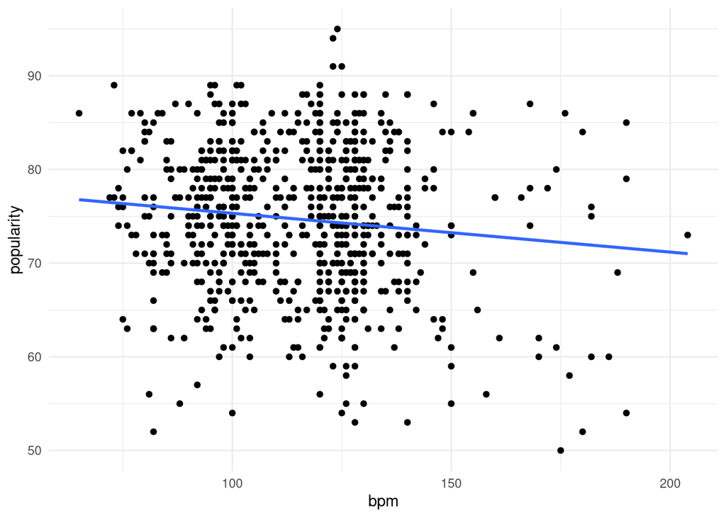

```r
p <- ggplot(songs, aes(x=bpm, y=popularity)) + geom_point() + geom_smooth(method = 'lm', se=FALSE) + theme_minimal()
p
```

The plot resembles a linear relationship.

#### *nrgy*

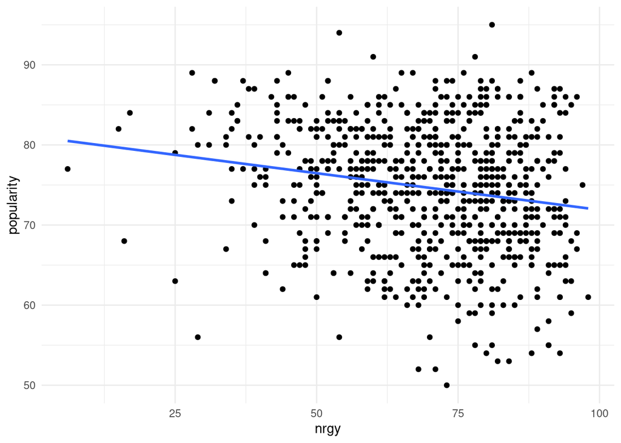

```r
p <- ggplot(songs, aes(x=nrgy, y=popularity)) + geom_point() + geom_smooth(method = 'lm', se=FALSE) + theme_minimal()
p
```

Once more, it is possible to se a linear relationship.

#### *dnce*

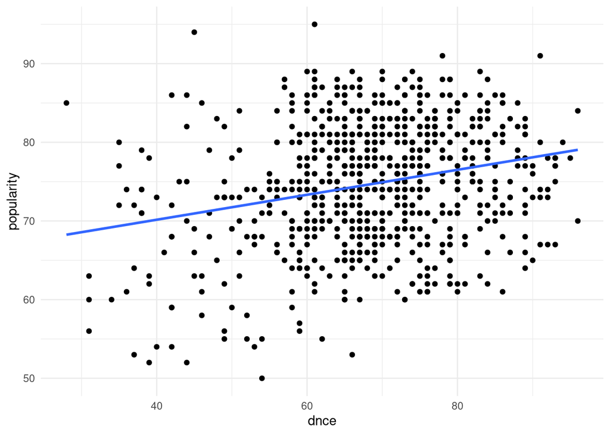

```r
p <- ggplot(songs, aes(x=dnce, y=popularity)) + geom_point() + geom_smooth(method = 'lm', se=FALSE) + theme_minimal()
p
```

Again, a linear relationship.

#### *dB*

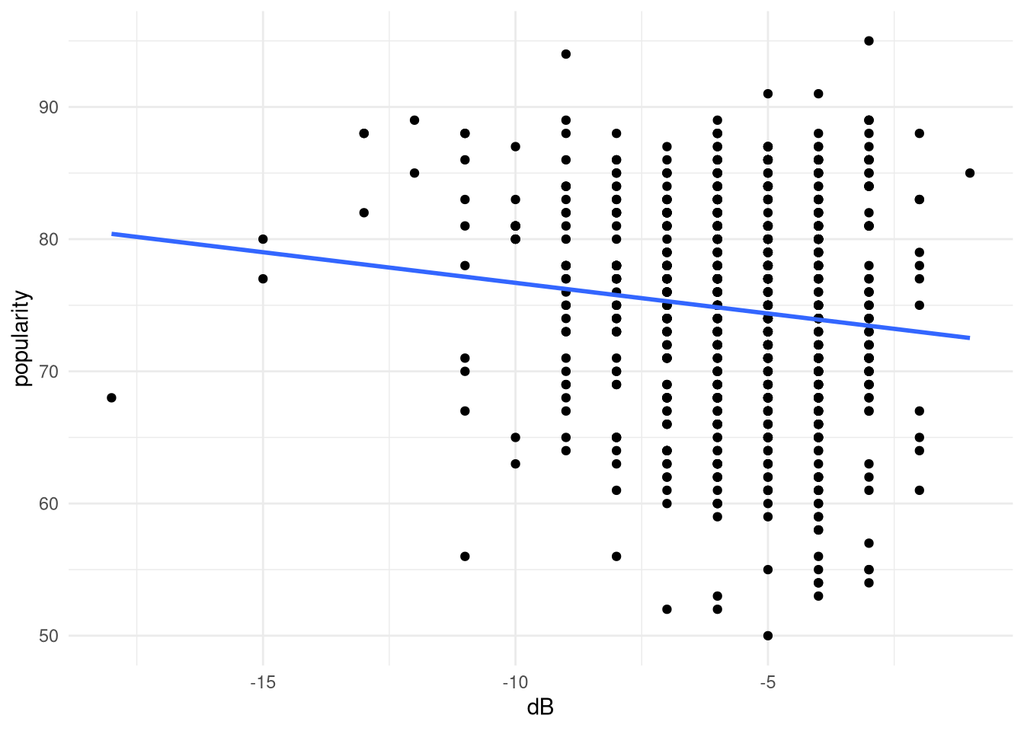

```r
p <- ggplot(songs, aes(x=dB, y=popularity)) + geom_point() + geom_smooth(method = 'lm', se=FALSE) + theme_minimal()
p
```

#### *live*

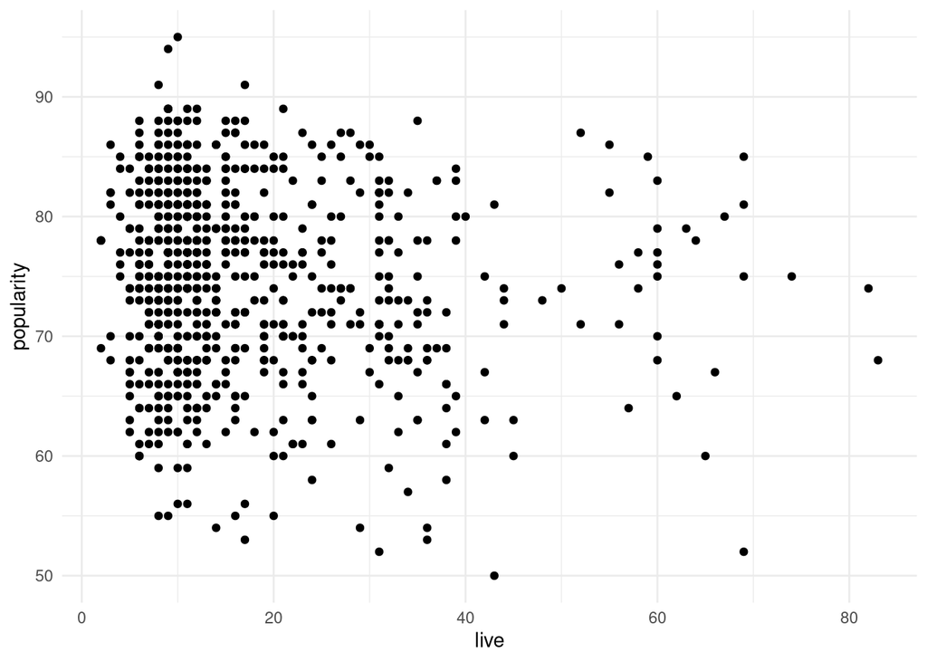

```r
p <- ggplot(songs, aes(x=live, y=popularity)) + geom_point() + theme_minimal()
p
```

This plot resembles a kind of logarithmic relationship. Let’s try a log transformation on the independent variable.

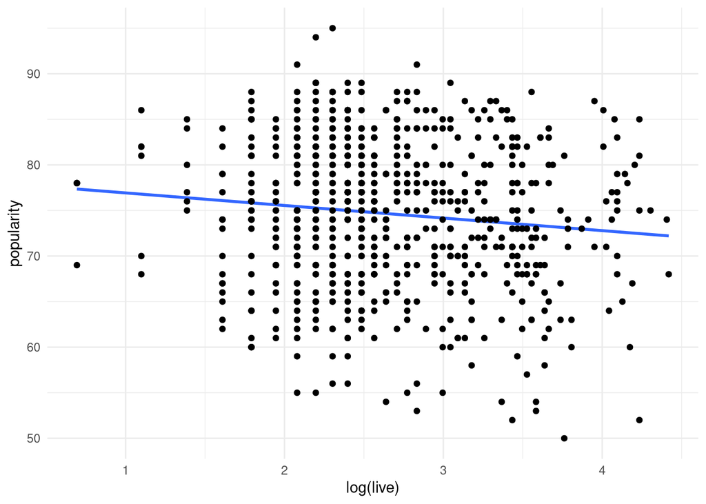

```r
p <- ggplot(songs, aes(x=log(live), y=popularity)) + geom_smooth(method = 'lm', se=FALSE) + geom_point() + theme_minimal()
p
```

This results in a apparently more linear relationship.

#### *val*

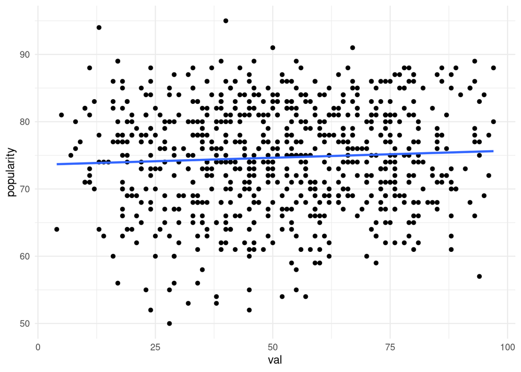

```r
p <- ggplot(songs, aes(x=val, y=popularity)) + geom_point() + geom_smooth(method = 'lm', se=FALSE) + theme_minimal()
p
```

Observations don’t show any pattern.

#### *dur*

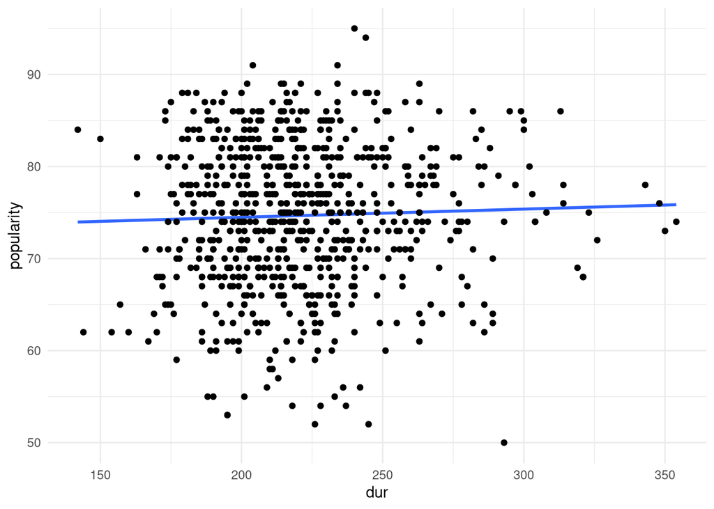

```r
p <- ggplot(songs, aes(x=dur, y=popularity)) + geom_smooth(method = 'lm', se=FALSE)+ geom_point()+ theme_minimal()
p
```

Observations are uniformly distributed in space.

#### *acous*

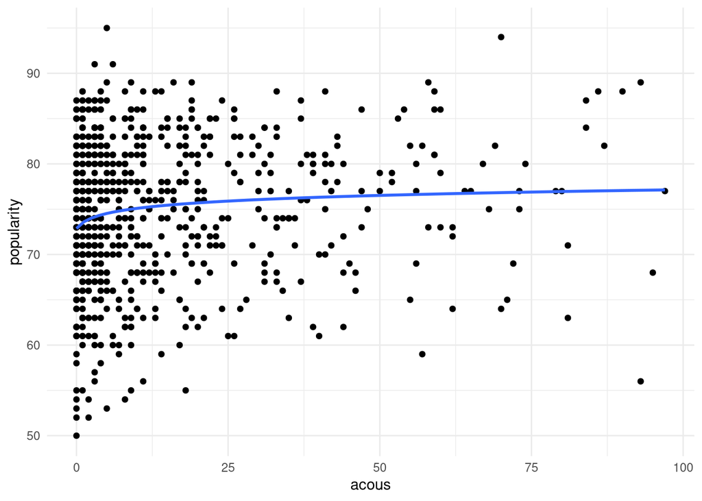

```r
p <- ggplot(songs, aes(x=acous, y=popularity)) + geom_point() + geom_smooth(method = 'lm', formula = y ~ log(x+1), se=FALSE) + theme_minimal()
p
```

The relationship between these two variables seems logarithmic. Let0s apply a log transformation on *acous*.

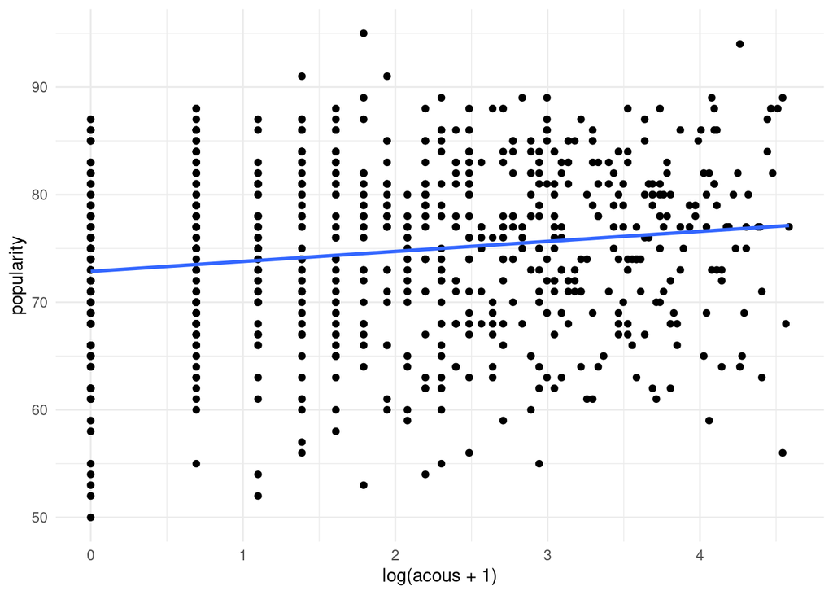

```r
p <- ggplot(songs, aes(x=log(acous + 1), y=popularity)) + geom_point() + geom_smooth(method = 'lm', se=FALSE) + theme_minimal()
p
```

The transformation resulted on a more linear relationship.

#### *spch*

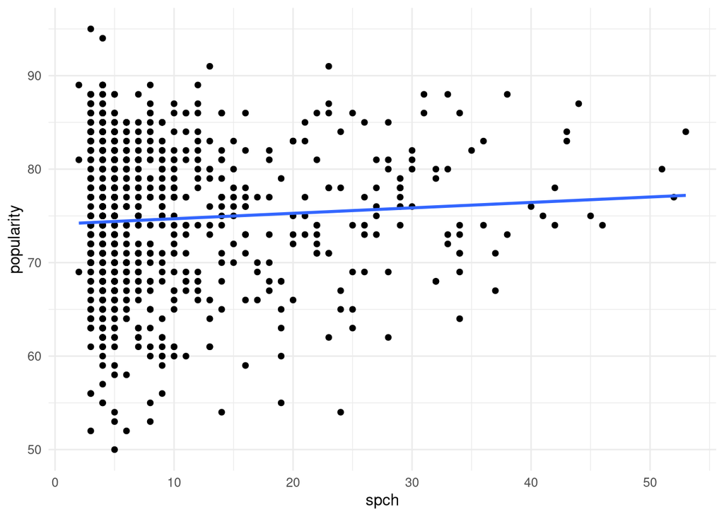

```r
p <- ggplot(songs, aes(x=spch, y=popularity)) + geom_point() + geom_smooth(method = 'lm', se=FALSE) + theme_minimal()
p
```

After examining the plots and the original correlations with the target it is possible to conclude that the variables *val*, *dur* and *spch* are not relevant for the analysis. The popularity of songs across these variables seems to be uniformly distributed, therefore they do not provide insights to better understand the reasons behind a song’s popularity.

### Summary of the possible transformations

After analyzing the previous plots, it seems reasonable that the best way of modeling the relationship between the target variable and the predictors is not always the level-level relationship. A summary of the possible best transformations for each variable is presented below.

[output not shown]

With this table it is possible to see that the functional forms that are most likely the ones that best model the relationship between the target and the regressors are: a level-level, a level-log or, finally, a mix of the previous ones, counting with a log transformation on only some of the regressors.

In the next stage, all these functional forms will be tested. For all the models, both *other* and *group* are the omitted default dummy variables.

### Level-Level Estimation

```r
level_level_reg = lm(popularity ~ bpm + nrgy + dnce + dB + live + acous + pop + rock + hip_hop + rap + solo, data = songs)

summary(level_level_reg)
```

```
##
## Call:
## lm(formula = popularity ~ bpm + nrgy + dnce + dB + live + acous +
##     pop + rock + hip_hop + rap + solo, data = songs)
##
## Residuals:
##      Min       1Q   Median       3Q      Max
## -19.4033  -5.0702   0.1639   5.2601  20.5431
##
## Coefficients:
##              Estimate Std. Error t value Pr(>|t|)
## (Intercept) 70.045848   3.705415  18.904  < 2e-16 ***
## bpm         -0.027831   0.012946  -2.150  0.03189 *
## nrgy        -0.039618   0.026429  -1.499  0.13429
## dnce         0.137283   0.023469   5.850  7.4e-09 ***
## dB           0.024159   0.190805   0.127  0.89928
## live        -0.045676   0.020971  -2.178  0.02971 *
## acous        0.038669   0.016825   2.298  0.02182 *
## pop          1.626703   0.714798   2.276  0.02315 *
## rock         4.985930   1.743432   2.860  0.00436 **
## hip_hop      2.803861   1.026678   2.731  0.00646 **
## rap          2.660219   1.359315   1.957  0.05072 .
## solo         0.004566   0.672503   0.007  0.99458
## ---
## Signif. codes:  0 '***' 0.001 '**' 0.01 '*' 0.05 '.' 0.1 ' ' 1
##
## Residual standard error: 7.417 on 739 degrees of freedom
## Multiple R-squared:  0.1145, Adjusted R-squared:  0.1013
## F-statistic: 8.688 on 11 and 739 DF,  p-value: 1.38e-14
```

### Level-log Estimation

```r
level_log_reg = lm(popularity ~ log(bpm) + log(nrgy) + log(dnce) + dB + log(live) + log(acous + 1) + pop + rock + hip_hop + rap + solo, data = songs)

summary(level_log_reg)
```

```
##
## Call:
## lm(formula = popularity ~ log(bpm) + log(nrgy) + log(dnce) +
##     dB + log(live) + log(acous + 1) + pop + rock + hip_hop +
##     rap + solo, data = songs)
##
## Residuals:
##      Min       1Q   Median       3Q      Max
## -19.3072  -5.0356   0.2582   5.2364  22.6466
##
## Coefficients:
##                Estimate Std. Error t value Pr(>|t|)
## (Intercept)    59.92773   11.69533   5.124 3.82e-07 ***
## log(bpm)       -2.82920    1.49323  -1.895  0.05852 .
## log(nrgy)      -2.31881    1.47717  -1.570  0.11690
## log(dnce)       8.94466    1.41308   6.330 4.25e-10 ***
## dB             -0.01734    0.19044  -0.091  0.92748
## log(live)      -1.05051    0.42410  -2.477  0.01347 *
## log(acous + 1)  0.66023    0.23273   2.837  0.00468 **
## pop             1.62483    0.71058   2.287  0.02250 *
## rock            5.10728    1.73141   2.950  0.00328 **
## hip_hop         2.82926    1.01377   2.791  0.00539 **
## rap             2.69837    1.34551   2.005  0.04528 *
## solo            0.04687    0.66752   0.070  0.94405
## ---
## Signif. codes:  0 '***' 0.001 '**' 0.01 '*' 0.05 '.' 0.1 ' ' 1
##
## Residual standard error: 7.369 on 739 degrees of freedom
## Multiple R-squared:  0.126,  Adjusted R-squared:  0.113
## F-statistic: 9.683 on 11 and 739 DF,  p-value: < 2.2e-16
```

### Mixed forms estimation

```r
mixed_reg = lm(popularity ~ bpm + nrgy + dnce + dB + log(live) + log(acous + 1) + pop + rock + hip_hop + rap + solo, data = songs)

summary(mixed_reg)
```

```
##
## Call:
## lm(formula = popularity ~ bpm + nrgy + dnce + dB + log(live) +
##     log(acous + 1) + pop + rock + hip_hop + rap + solo, data = songs)
##
## Residuals:
##      Min       1Q   Median       3Q      Max
## -19.0622  -5.0410   0.2956   5.1972  20.5864
##
## Coefficients:
##                Estimate Std. Error t value Pr(>|t|)
## (Intercept)    71.05253    3.86413  18.388  < 2e-16 ***
## bpm            -0.02597    0.01294  -2.007  0.04507 *
## nrgy           -0.03788    0.02609  -1.452  0.14695
## dnce            0.13146    0.02326   5.651 2.27e-08 ***
## dB             -0.01851    0.18954  -0.098  0.92225
## log(live)      -1.06534    0.42564  -2.503  0.01253 *
## log(acous + 1)  0.67491    0.23276   2.900  0.00385 **
## pop             1.65129    0.71263   2.317  0.02077 *
## rock            5.06069    1.73817   2.912  0.00371 **
## hip_hop         2.81753    1.02065   2.761  0.00591 **
## rap             2.70437    1.35485   1.996  0.04629 *
## solo            0.03489    0.67036   0.052  0.95850
## ---
## Signif. codes:  0 '***' 0.001 '**' 0.01 '*' 0.05 '.' 0.1 ' ' 1
##
## Residual standard error: 7.396 on 739 degrees of freedom
## Multiple R-squared:  0.1195, Adjusted R-squared:  0.1064
## F-statistic: 9.115 on 11 and 739 DF,  p-value: 2.095e-15
```